# Homework 3: Spark, RDDs, DF

E-63 Big Data Analytics Harvard University, Autumn 2017

Tim Hagmann

September 20, 2017

# Introduction

The following assignement is concerned with the installation and application of Apache Spark. Spark is an open-source cluster-computing framework which provides programmers with an application programming interface (API). It was developed in response to limitations in the MapReduce cluster computing paradigm, which forces a particular linear dataflow structure on distributed programs: MapReduce programs read input data from disk, map a function across the data, reduce the results of the map, and store reduction results on disk. Spark provides an interface for programming entire clusters with implicit data parallelism and fault-tolerance.

# Problem 1 (20%)

Create your own Virtual Machine with a Linux operating system. The lecture notes speak about CentOS. You are welcome to work with another Linux OS. When creating the VM, create an administrative user. Call that user whatever you feel like.

## Create AWS instance

As stated on Piazza, instead of using a VM it is also possible to create a AWS instance. Spark is a cluster-computing framework. Because of this, a sensible approach is to install it on AWS in order to leverage those cluster capabilities.

**Note:** There are in principal two ways starting up a AWS instance, one is working with the web based *point and click* interface and the other is to use the *command-line interface (CLI)*. We’re using the second option here. The reason for this is, that when working with clusters using a startup script can be significantly faster and is more fault-tolerant than configuring the cluster by hand.

#### Step 1: Installing AWS CLI

First, we have to install the AWS CLI on the local bash client (e.g., WSL for Windows, terminal on Linux, etc.)

```bash
sudo apt install awscli -y
```

#### Step 2: Configure AWS CLI

Second, we have to configure the AWS CLI, in order to do this, a user has to be created under: https://console.aws.amazon.com/iam/home#/users. With the information of the user data the AWS CLI can be configured.

```bash
# configuring AWSCLI
aws configure

# 1. enter your Access Key ID
# 2. enter your Secret Access Key
# 3. choose region close to you [*] (e.g., "eu-central-1")
# 4. enter "json"
```

#### Step 3: Creating a SSH Key pair

In order to ssh into the AWS instance, a SSH Key has to be created and downloaded:

```bash
# Creat SSH Key pair
aws ec2 create-key-pair --region eu-central-1 --key-name aws-instance \
    --query "KeyMaterial" --output text > SSH/aws-instance.pem
```

#### Step 4: Network & Security

Next we’re setting up the network and security settings. Out of convinience, we’re allowing all IP addresses to access our AWS Server. We’re also oppening the port 22 (ssh), 80 (http), 443 (https), 8787 (rstudio) and 4040, 4041, 7077 (Spark).

```bash
# set MYIP to external IP address
MYIP=$(curl -s http://myip.dnsomatic.com | grep -P '[\d.]')

# set ALLIP to 0.0.0.0/0
ALLIP="0.0.0.0/0"

echo $MYIP
echo $ALLIP

# create a new security group and save its returned ID to SGID
SGID=$(aws ec2 create-security-group --group-name aws-sec-group \
       --description "aws security group" --region eu-central-1)

# allow all IP's access to ports
aws ec2 authorize-security-group-ingress --group-name aws-sec-group \
    --protocol tcp --port 22 --cidr $ALLIP --region eu-central-1
aws ec2 authorize-security-group-ingress --group-name aws-sec-group \
    --protocol tcp --port 80 --cidr $ALLIP --region eu-central-1
aws ec2 authorize-security-group-ingress --group-name aws-sec-group \
    --protocol tcp --port 8787 --cidr $ALLIP --region eu-central-1
aws ec2 authorize-security-group-ingress --group-name aws-sec-group \
    --protocol tcp --port 443 --cidr $ALLIP --region eu-central-1
aws ec2 authorize-security-group-ingress --group-name aws-sec-group \
    --protocol tcp --port 4040 --cidr $ALLIP --region eu-central-1
aws ec2 authorize-security-group-ingress --group-name aws-sec-group \
    --protocol tcp --port 4041 --cidr $ALLIP --region eu-central-1
aws ec2 authorize-security-group-ingress --group-name aws-sec-group \
    --protocol tcp --port 7077 --cidr $ALLIP --region eu-central-1
```

#### Step 5: Launch EC2 Instance

With the above network and security settings we’re launching a free-tier Ubuntu 16.04 Ubuntu instance. The only change that is done to the default settings is to increase the root disk space from 8GB to 32GB.

```bash
# Launch Instance (Ubuntu 16.04)
aws ec2 run-instances \
    --image-id ami-1e339e71 \
    --count 1 \
    --instance-type t2.micro \
    --key-name aws-instance \
    --security-group-ids aws-sec-group \
    --region eu-central-1 \
    --block-device-mapping \
    "[ { \"DeviceName\": \"/dev/sda1\", \"Ebs\": { \"VolumeSize\": 32 } } ]"
```

#### Step 6: Associate IP Address

The started instance has currently a *flexible* ip address. This means, that when restarting the instance, a new ip address gets associated to the server. In order to avoid this, we can associate a elastic ip address to the server. First we’re reading the id of our instance and the bought elastic ip address.

```bash
# Get instances id
aws ec2 describe-instances --query \
  'Reservations[].Instances[].[InstanceId, State.Name]' --output text
```

```
## i-0d52c859a139da090  running
```

```bash
# Get elastic IP addresses
x=$(aws ec2 describe-addresses)
y=$(echo $x | awk '{print $2}')
echo $y
```

```
## eipalloc-a26c62cb
```

With the above instance id (i-0d52c859a139da090) and elastic ip id (eipalloc-a26c62cb) we can associate the IP address.

```bash
# Associate IP address
aws ec2 associate-address --instance-id i-0d52c859a139da090 \
  --allocation-id eipalloc-a26c62cb
```

#### Step 7: SSH into EC2 Instance

Having associated instance **ip_address** (xx.xx.xxx.xx) we can now ssh into the server.

```bash
# SSH into instance
ssh -i SSH/aws-instance.pem ubuntu@<ip_address>
```

#### Step 8: Add user

We’re next adding a new user and are coping the ssh key to that user.

```bash
# Add new user
sudo adduser tim
sudo adduser tim sudo

# Copy ssh key
sudo mkdir /home/tim/.ssh
sudo cp /home/ubuntu/.ssh/authorized_keys \
    /home/tim/.ssh/authorized_keys
sudo cp /home/ubuntu/.ssh/authorized_keys \
    /home/tim/.ssh/authorized_keys
sudo chown tim -R /home/tim/.ssh
sudo chmod 700 /home/tim/.ssh
sudo chmod 600 /home/tim/.ssh/authorized_keys
```

#### Step 9: Enable Swapping (optional)

Because of the limited amount of RAM it might be necessary to enable swapping. This isn’t necessary the case when using bigger instances.

```bash
sudo /bin/dd if=/dev/zero of=/var/swap.1 bs=1M count=2048
sudo /sbin/mkswap /var/swap.1
sudo chmod 600 /var/swap.1
sudo /sbin/swapon /var/swap.1
```

#### Step 10: Install RStudio Server (optional)

In order to facilitate working with the spark instance, the RStudio Server IDE can be installed. The following bash script facilitates the installation.

```bash
wget https://cdn.rawgit.com/greenore/linux-setup/7d25ec0c/setup_rstudio.sh
chmod +x setup_rstudio.sh
sudo ./setup_rstudio.sh
```

#### Step 10: Install Java and Scala

Next we have to install java as spark is dependend on a correct java installation. We’re also installing the sbt client

```bash
# Install OpenJDK and scala
sudo apt install default-jre default-jdk scala -y

# Install sbt
echo "deb https://dl.bintray.com/sbt/debian /" \
  | sudo tee -a /etc/apt/sources.list.d/sbt.list
sudo apt-key adv --keyserver hkp://keyserver.ubuntu.com:80 \
  --recv 2EE0EA64E40A89B84B2DF73499E82A75642AC823
sudo apt-get update
sudo apt install sbt -y
```

## SCP file transfer

Once the VM is created transfer the attached text file Ulysses10.txt to the home of new user. You can do it using scp (secure copy command) or email.

In order to transfer the file trough SCP from the machine to the server we can open a second terminal on the local computer and the following command is transfering the file to the server.

```bash
scp -i SSH/aws-instance.pem \
  /mnt/c/Local/Education/e63-coursework/hw3/data/ulysses10.txt \
  tim@<ip_address>:~/.
```

**Note:** In this project all the files are transfer trough git over a github account. That means the above code is not actually executed.

## Java, Python, Scala and R

Examine the version of Java, Python and Scala on your VM. If any of those versions is below requirements for Spark 2.2 install proper version. Set JAVA_HOME environmental variable. Set your PATH environmental variable properly, so that you can invoke: java, sbt and python commands from any directory on your system.

#### Spark version check

Spark runs on Java 8+, Python 2.7+/3.4+ and R 3.1+. For the Scala API, Spark 2.2.0 uses Scala 2.11. As we’re not going to use the scala API, the sbt client doesn’t need to be installed.

#### Get Java version

```bash
java -version
```

```
## openjdk version "1.8.0_131"
## OpenJDK Runtime Environment (build 1.8.0_131-8u131-b11-2ubuntu1.16.04.3-b11)
## OpenJDK 64-Bit Server VM (build 25.131-b11, mixed mode)
```

#### Get Python version

```bash
python -V
```

```
## Python 2.7.12
```

#### Get R version

```bash
R --version
```

```
## R version 3.4.1 (2017-06-30) -- "Single Candle"
## Copyright (C) 2017 The R Foundation for Statistical Computing
## Platform: x86_64-pc-linux-gnu (64-bit)
##
## R is free software and comes with ABSOLUTELY NO WARRANTY.
## You are welcome to redistribute it under the terms of the
## GNU General Public License versions 2 or 3.
## For more information about these matters see
## http://www.gnu.org/licenses/.
```

#### Get Scala version

```bash
scala -version
```

```
## Scala code runner version 2.11.6 -- Copyright 2002-2013, LAMP/EPFL
```

#### Get Sbt version

```bash
sbt sbtVersion
```

```
## [info] Loading project definition from /home/tim/project
```

```
## [info] Set current project to tim (in build file:/home/tim/
```

```
## [info] 1.0.1
```

The above outputs show, that the necessary software is up to date. Next we’re setting the necessary path variables for JAVA_HOME. In order to do this we’re creating a bash_profile file with the following content:

```bash
# Get the aliases and functions
if [ -f ~/.bashrc ]; then
    . ~/.bashrc
fi

# JAVA_HOME environment
JAVA_HOME=/usr/lib/jvm/java-8-openjdk-amd64/jre/
export JAVA_HOME

PATH=$PATH:$JAVA_HOME/bin
export PATH
```

That file has to be sourced in order to be effective.

```bash
source ~/.bash_profile
```

# Problem 2 (15%)

Install Spark 2.2 on your VM. Make sure that pyspark is also installed. Demonstrate that you can successfully open spark-shell and that you can eliminate most of WARNing messages.

## Install Spark

There are multiple ways to install spark on the EC2 instance. An easy way would be to use the spark_install function inside the sparklyr package. We’re using the default installation process trough downloading the tgz file from apache.

```bash
# Download Spark
sudo wget https://d3kbcqa49mib13.cloudfront.net/spark-2.2.0-bin-hadoop2.7.tgz

# Unpack Spark in the /opt directory
sudo tar zxvf spark-2.2.0-bin-hadoop2.7.tgz -C /opt
```

Next we have to add SPARK_HOME to the bash_profile file. The new file is going to look like this:

```bash
# Get the aliases and functions
if [ -f ~/.bashrc ]; then
    . ~/.bashrc
fi

# JAVA_HOME environment
JAVA_HOME=/usr/lib/jvm/java-8-openjdk-amd64/jre/
export JAVA_HOME

SPARK_HOME=/opt/spark-2.2.0-bin-hadoop2.7/
export SPARK_HOME

PATH=$PATH:$JAVA_HOME/bin:$SPARK_HOME/bin
export PATH
```

That file has to be sourced in order to be effective.

```bash
source ~/.bash_profile
```

## Spark config

** Note: ** When launching spark a metastore_db directory and the derby.log file are being created at the start-up location. Working with a version control system this behavior is rather annoying (i.e., version controling a database doesn’t make a lot of sense). However, the default location of the folder can be specified in the *spark-defaults.conf* file. This is what we’re going to do:

```bash
# Rename spark-defaults
sudo cp /opt/spark-2.2.0-bin-hadoop2.7/conf/spark-defaults.conf.template \
  /opt/spark-2.2.0-bin-hadoop2.7/conf/spark-defaults.conf

# Append line to the file
echo 'spark.driver.extraJavaOptions -Dderby.system.home=/tmp/derby' | \
  sudo tee --append /opt/spark-2.2.0-bin-hadoop2.7/conf/spark-defaults.conf
```

## Check Pyspark

In order to check if pyspark is installed we can run the pyspark command

[figure not shown]

```bash
pyspark
```

The image above shows, that pyspark does work.

## Eliminate warnings

Demonstrate that you can successfully open spark-shell and that you can eliminate most of WARNing messages.

In order to eliminate the error messages in the spark-shell we’re first creating the log4j.properties file from the template file and setting the log level to ERROR and log4j.rootCategory=ERROR.

```bash
# Create log4j.properties
sudo mv /opt/spark-2.2.0-bin-hadoop2.7/conf/log4j.properties.template \
  /opt/spark-2.2.0-bin-hadoop2.7/conf/log4j.properties

# Edit file
sudo nano /opt/spark-2.2.0-bin-hadoop2.7/conf/log4j.properties
```

## Check Spark-Shell

In order to check if the error messages disappeared from spark-shell we can run the following command:

[figure not shown]

```bash
spark-shell
```

The image above shows, that spark-shell runs correctly.

# Problem 3 (15%)

Find the number of lines in the text file ulysses10.txt that contain word *“afternoon”* or *“night”* or *“morning”*. In this problem use RDD API. Do this in two ways, first create a lambda function which will test whether a line contains any one of those 3 words.

#### Install findspark

We’re going to use the standard python 2.7 interpreter to solve the above problem. In order to do this we’re first installing findspark with pip

```bash
sudo -H pip install findspark
```

## i) Lambda function (RDD)

Next we’re using a lambda function to count the number of *night*, *morning* and *afternoon* occurrences in the text.

```python
# Import findspark
import findspark
findspark.init("/opt/spark-2.2.0-bin-hadoop2.7")

from pyspark import SparkContext, SparkConf

conf = SparkConf().setMaster("local").setAppName("p3_rdd_lambda")
sc = SparkContext(conf = conf)

rdd_lines = sc.textFile("file:///home/tim/e63-coursework/hw3/data/ulysses10.txt")

rdd_filt_words = rdd_lines.filter(lambda line: "night" in line or "morning" in
                                  line or "afternoon" in line)

print "Number of lines with 'morning', 'afternoon', 'night':"
print rdd_filt_words.count()
sc.stop()
```

```
## Number of lines with 'morning', 'afternoon', 'night':
## 418
```

## ii) Named function (RDD)

Second, create a named function in the language of choice that returns TRUE if a line passed to it contains any one of those three words. Demonstrate that the count is the same. Use pyspark and Spark Python API.

```python
# Import findspark
import findspark
findspark.init("/opt/spark-2.2.0-bin-hadoop2.7")
from pyspark import SparkConf, SparkContext

conf = SparkConf().setMaster("local").setAppName("p3_rdd_function")
sc = SparkContext(conf = conf)

# Define function
def has_word_in(line):
    return ("night" in line or "morning" in line or "afternoon" in line)

rdd_lines = sc.textFile("file:///home/tim/e63-coursework/hw3/data/ulysses10.txt")
rdd_linematch = rdd_lines.filter(has_word_in)

print "Number of lines with 'morning', 'afternoon', 'night':"
print rdd_linematch.count()
sc.stop()
```

```
## Number of lines with 'morning', 'afternoon', 'night':
## 418
```

# Problem 4 (15%)

Implement the above task, finding the number of lines with one of those three words in file ulysses10.txt using Dataset/DataFrame API.

## Word count (DF)

Using the dataframe API requires to use different syntax. Furthermore, the session is also created in a different fashion.

```python
# Import libraries
import findspark
findspark.init("/opt/spark-2.2.0-bin-hadoop2.7")
from pyspark.sql import SparkSession

# Create Session
spark = SparkSession.builder.master("local").appName("p4_df_filter_count").getOrCreate()

# Read data
tbl_ulysses = spark.read.text("file:///home/tim/e63-coursework/hw3/data/ulysses10.txt")

tbl_lines = tbl_ulysses.filter(tbl_ulysses.value.contains('afternoon') |
                               tbl_ulysses.value.contains('night') |
                               tbl_ulysses.value.contains('morning'))

print "Number of lines with 'morning', 'afternoon', 'night':"
print tbl_lines.count()
```

```
## Number of lines with 'morning', 'afternoon', 'night':
## 418
```

# Problem 5 (15%)

Create a standalone Python script that will count all words in file ulysses10.txt. You are expected to produce a single number. Do it using RDD API.

## Total word count (RDD)

```python
# Import findspark
import findspark
findspark.init("/opt/spark-2.2.0-bin-hadoop2.7")
from pyspark import SparkConf, SparkContext

# Configuration
conf = SparkConf().setMaster("local") \
                  .setAppName("p5_rdd_count")

# Load Spark
sc = SparkContext(conf = conf)

# Load data
rdd_lines = sc.textFile("file:///home/tim/e63-coursework/hw3/data/ulysses10.txt")

# Map and reduce data
rdd_counts = rdd_lines.flatMap(lambda x: x.split(' ')) \
                      .map(lambda x: (x, 1)) \
                      .reduceByKey(lambda x, y : x + y) \
                      .map(lambda x : x[1]).sum()

# Print
print "Total word count:"
print rdd_counts
sc.stop()
```

With the below bash command we can run the above python script:

```bash
# Execute python script
/opt/spark-2.2.0-bin-hadoop2.7/bin/spark-submit \
  /home/tim/e63-coursework/hw3/scripts/p5_rdd_word_count.py
```

```
## Total word count:
## 278555
```

It shows that we count 278’555 words. The code could be refined some more by putting all words into lower case and eliminating numbers and punctuation marks (See the reference links for some more). However, in order for the solution to be easily comparable I’m leaving it at the current state.

# Problem 6 (15%)

Create a standalone Python script that will count all words in file ulysses10.txt. You are expected to produce a single number. Do it using Dataset/DataFrame API.

## i) Total word count (DF)

We could simply use the *rdd* function and use the same building blocks as before. However, using the dataframe gives new ways of manipulating the data.

```python
# Import libraries
import findspark
findspark.init("/opt/spark-2.2.0-bin-hadoop2.7")
from pyspark.sql import SparkSession
from pyspark.sql.functions import split   # Function to split data
from pyspark.sql.functions import explode # Equivalent to flatMap

# Create Session
spark = SparkSession.builder.master("local").appName("p6_df_count").getOrCreate()

# Read data
df = spark.read.text("file:///home/tim/e63-coursework/hw3/data/ulysses10.txt")

# First we're spliting each of the lines into words using the split function.
# This will create a new dataframe with the words column, each words column
# has an array of words for that line.
words_df = df.select(split(df.value, " ").alias("words"))

# Next we're using the explode function to convert the words array into
# a dataframe with word column. This is equivalent of using flatMap() method on RDD
word_df = words_df.select(explode(words_df.words).alias("word"))

print("Number of words: ")
print(word_df.count())
```

```bash
# Execute python script
/opt/spark-2.2.0-bin-hadoop2.7/bin/spark-submit \
  /home/tim/e63-coursework/hw3/scripts/p6_df_word_count.py
```

```
## Number of words:
## 278555
```

## ii) Number of unique words

Having done this we can easily also count the number of unique words with the following two lines.

```python
# Get unique words
word_count_df = word_df.groupBy("word").count()

print("Number of unique words: ")
print(word_count_df.count())
```

```
## Number of unique words:
##
[Stage 1:=================>                                      (64 + 1) / 200]
[Stage 1:===========================>                           (100 + 1) / 200]
[Stage 1:====================================>                  (132 + 1) / 200]
[Stage 1:==============================================>        (168 + 1) / 200]

52983
```

The results are the same as before, we’re counting 278’555 words. As said before, we didn’t exlude any commas, points etc.

## iii) SparkR (optional)

The SparkR packages allows accessing the dataframe api directly from R. In order to have an comparable example out of R we’re replicating the above answer in R.

#### Start session

```r
if (nchar(Sys.getenv("SPARK_HOME")) < 1) {
  suppressMessages(Sys.setenv(SPARK_HOME = "/opt/spark-2.2.0-bin-hadoop2.7/"))
}

suppressMessages(library(SparkR, lib.loc = c(file.path(Sys.getenv("SPARK_HOME"),
                                                       "R", "lib"))))

suppressMessages(sparkR.session(master="local",
                                sparkConfig=list(spark.driver.memory="2g",
                                                 app_name = "p6_df_count")))
```

```
## Launching java with spark-submit command /opt/spark-2.2.0-bin-hadoop2.7//bin/spark-submit   --driver-memory "2g" sparkr-shell /tmp/RtmpUS5G3n/backend_port58064b39a95
```

```
## Java ref type org.apache.spark.sql.SparkSession id 1
```

#### Get data

```r
# install.packages("magrittr")
library(magrittr)

df <- read.text("/home/tim/e63-coursework/hw3/data/ulysses10.txt")
seperated <- selectExpr(df, "split(value, ' ') AS value")

words <- select(seperated, explode(seperated$value)) %>%
  collect() %>%
  extract2(1)

length(words)
```

```
## [1] 278555
```

We can see that we count the same amount of words as with the python example. However, as mentioned before, the counted words are not properly cleaned. We have to remove all punctuations, turn all the words into lower case and remove empty lines and remove duplicates. That is what we’re going to do next.

#### Get data

```r
# install.packages("magrittr")
library(magrittr)

df <- read.text("/home/tim/e63-coursework/hw3/data/ulysses10.txt")
df <- filter(df, "value != ''")
df$value <- lower(df$value)
df$value <- regexp_replace(df$value, pattern="[^\\w || \\s]", replacement = "")
seperated <- selectExpr(df, "split(value, ' ') AS value")

words <- select(seperated, explode(seperated$value)) %>%
  distinct() %>%
  collect() %>%
  extract2(1)

words <- words[words != ""]
length(words)
```

```
## [1] 29979
```

As can be seen above, the amount of words has decreased to 29’979 unique words. Next we’re going to explore the frequency of the words. For that we have to include all the words.

```r
df <- filter(df, "value != ''")
df$value <- lower(df$value)
df$value <- regexp_replace(df$value, pattern="[^\\w || \\s]", replacement = "")
seperated <- selectExpr(df, "split(value, ' ') AS value")

words <- select(seperated, explode(seperated$value)) %>%
  collect() %>%
  extract2(1)

words <- words[words != ""]
```

Having a dataframe with unique words lets visualize those words.

#### Plotting

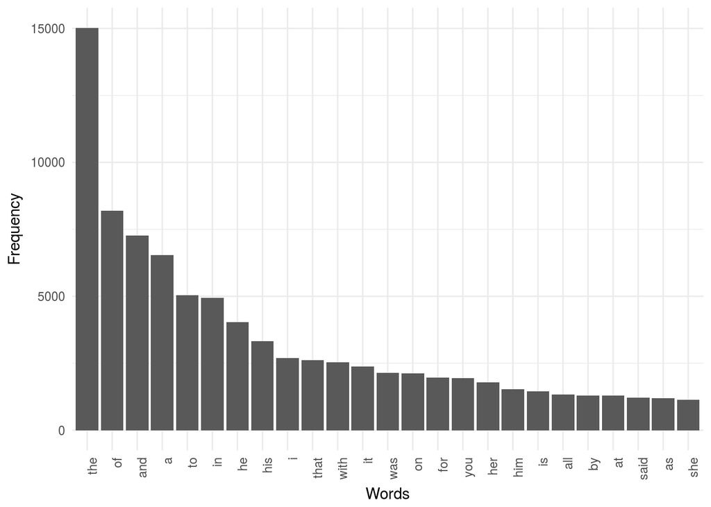

```r
library(ggplot2)

# Data manipulation
df_words <- data.frame(table(words))
df_words <- df_words[order(df_words$Freq, decreasing=TRUE), ]
df_words$words <- factor(df_words$words,
                         levels=df_words$words[
                           order(df_words$Freq, decreasing=TRUE)])

# Plotting
ggplot(df_words[1:25, ], aes(words, Freq)) +
  geom_bar(stat="identity") +
  theme_minimal() +
  ylab("Frequency") +
  xlab("Words") +
  theme(axis.text.x = element_text(angle = 90, hjust = 1))
```

The plot above shows, that the most used words are as expecet filler words. Lets go further and visualize all the words in a wordcloud.

```r
# install.packages("wordcloud2")
library(wordcloud2)

# Change the shape using your image
wordcloud2(df_words, size = 1.5, color = "black", backgroundColor="white")
```

[interactive chart not shown]

# References

In order to solve some of the above problems I used the following source.

Source: http://www.sparktutorials.net/Getting+Started+with+Apache+Spark+RDDs

Source: https://datamize.wordpress.com/2015/02/08/visualizing-basic-rdd-operations-through-wordcount-in-pyspark/

Source: http://www.mccarroll.net/blog/pyspark2/index.html